# Week2-Data Management

Matthew Onimus

2020-09-18

```r
library(tidyverse)
library(gtsummary)
library(gt)
library(haven)
library(readxl)
library(rlang)
library(corrplot)
```

# Reading in the Data

The first thing I needed to do was read the data in join as per the SAS script.

```r
nhanesdemo <- read_sav("assignments/NHANES_2015_DEMO.sav")
nhanesbmx <- read_csv("assignments/NHANES_2015_BMX_I.csv")
nhaneshosp <- read_excel("assignments/NHANES_2015_HUQ.xlsx")

# note that all the data is not the same legnth

nhanes <- nhanesdemo %>%
  left_join(nhanesbmx, by = "SEQN") %>%
  left_join(nhaneshosp, by = "SEQN")

tbl_summary(nhanes)
```

| **Characteristic** | **N = 9,971**<sup>1</sup> |
| --- | --- |
| Respondent sequence number | 88,717 (86,224, 91,210) |
| Data release cycle |  |
| 9 | 9,971 (100%) |
| Interview/Examination status |  |
| 1 | 427 (4.3%) |
| 2 | 9,544 (96%) |
| Gender |  |
| 1 | 4,892 (49%) |
| 2 | 5,079 (51%) |
| Age in years at screening | 27 (9, 53) |
| Age in months at screening - 0 to 24 mos | 10 (5, 17) |
| Unknown | 9,276 |
| Race/Hispanic origin |  |
| 1 | 1,921 (19%) |
| 2 | 1,308 (13%) |
| 3 | 3,066 (31%) |
| 4 | 2,129 (21%) |
| 5 | 1,547 (16%) |
| Race/Hispanic origin w/ NH Asian |  |
| 1 | 1,921 (19%) |
| 2 | 1,308 (13%) |
| 3 | 3,066 (31%) |
| 4 | 2,129 (21%) |
| 6 | 1,042 (10%) |
| 7 | 505 (5.1%) |
| Six month time period |  |
| 1 | 4,594 (48%) |
| 2 | 4,950 (52%) |
| Unknown | 427 |
| Age in months at exam - 0 to 19 years | 100 (41, 162) |

[output cut: 289 more lines]

<sup>*1*</sup> Statistics presented: median (IQR); n (%)

The final, joined data had 81 variables and 9971 observations. A pretty massive dataset.

## 1. Review the frequency table for the number of overnight hospital visits and a histogram, what is this data and distribution telling you?

```r
nhanes2 <- nhanes %>%
  #select(HUD080, HUQ071) %>%
  mutate(overnightHosp = HUD080,
         overnightHosp = ifelse(HUQ071==7 | HUQ071==9 | is.na(HUQ071), NA, overnightHosp),
         overnightHosp = ifelse(HUQ071 == 1 & (HUD080 == 77777 | HUD080 == 99999), NA, overnightHosp),
         overnightHosp = ifelse(HUQ071 == 2, 0, overnightHosp),
         waistin = BMXWAIST / 2.54,
         children = 0,
         children = ifelse(DMDHHSZA > 0 | DMDHHSZB > 0, 1, children)

  )

nhanesChildren <- nhanes2 %>%
  filter(children == 1)

nhanes2 %>%
  select(overnightHosp) %>%
  group_by(overnightHosp) %>%
  summarise(count = n()) %>%
  gt()
```

| overnightHosp | count |
| --- | --- |
| 0 | 9098 |
| 1 | 630 |
| 2 | 141 |
| 3 | 55 |
| 4 | 18 |
| 5 | 14 |
| 6 | 10 |
| NA | 5 |

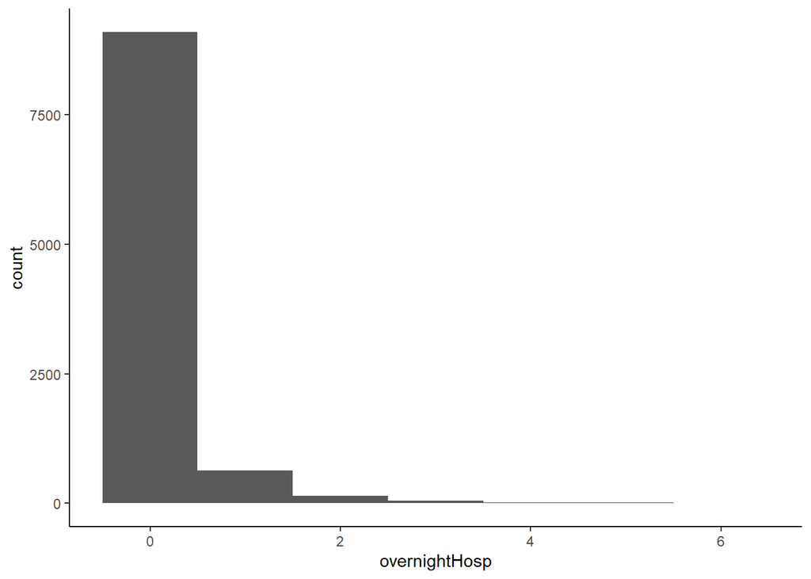

```r
ggplot(nhanes2, aes(x = overnightHosp)) +
  geom_histogram(bins = 7) +
  theme_classic()
```

### Answer:

The frequency table shows most of the data do not have an overnight hospital stay. The histogram tells the same story. There is a large tail to the data showing the skewness.

## 2. What is the median age of respondents? What are the median ages for those who do and do not have a child in the home?

```r
median(nhanes2$RIDAGEYR)
```

```
## [1] 27
```

```r
nhanes2 %>%
  group_by(children) %>%
  summarise(count = n(),
            median = median(RIDAGEYR))
```

```
## # A tibble: 2 x 3
##   children count median
##      <dbl> <int>  <dbl>
## 1        0  3330     59
## 2        1  6641     14
```

### Answer:

The median age for all respondents is 27. The median age for those with children is 14 and without children is 59.

## 3. What is the average waist circumference (in inches) for those who had 6+ overnight hospital stays in the past year?

```r
nhanes2 %>%
  group_by(overnightHosp) %>%
  summarize(count = n(),
            waist = mean(waistin, na.rm = TRUE)) %>%
  gt()
```

| overnightHosp | count | waist |
| --- | --- | --- |
| 0 | 9098 | 34.30683 |
| 1 | 630 | 38.39725 |
| 2 | 141 | 40.62992 |
| 3 | 55 | 39.03864 |
| 4 | 18 | 39.01247 |
| 5 | 14 | 34.54068 |
| 6 | 10 | 36.84055 |
| NA | 5 | 35.27559 |

### Answer:

The average waist size (in inches) for 6 overnight stays is 36.841 inches.

## 4. Create a cross-tabulation for the number of overnight hospital stays with race/ethnicity (RIDRETH3). Which group had the lowest proportion on inpatients? The greatest proportion of high utilizers?

```r
nhanes2 %>%
  select(overnightHosp, RIDRETH3) %>%
  tbl_summary(by = RIDRETH3, percent = 'cell') %>%
  add_overall() %>%
  as_gt() %>%
  #tab_header(title = "Table of overnighthosp by RIDRETH3") %>%
  tab_spanner(label = "RIDRETH3(Race/Hispanic origin w/ NH Asian)", columns = c(5:10))
```

| **Characteristic** | **Overall**, N = 9,971 | RIDRETH3(Race/Hispanic origin w/ NH Asian) **1**, N = 1,921<sup>1</sup> | RIDRETH3(Race/Hispanic origin w/ NH Asian) **2**, N = 1,308<sup>1</sup> | RIDRETH3(Race/Hispanic origin w/ NH Asian) **3**, N = 3,066<sup>1</sup> | RIDRETH3(Race/Hispanic origin w/ NH Asian) **4**, N = 2,129<sup>1</sup> | RIDRETH3(Race/Hispanic origin w/ NH Asian) **6**, N = 1,042<sup>1</sup> | RIDRETH3(Race/Hispanic origin w/ NH Asian) **7**, N = 505<sup>1</sup> |
| --- | --- | --- | --- | --- | --- | --- | --- |
| overnightHosp |  |  |  |  |  |  |  |
| 0 | 9,098 (91%) | 1,782 (18%) | 1,178 (12%) | 2,802 (28%) | 1,909 (19%) | 981 (9.8%) | 446 (4.5%) |
| 1 | 630 (6.3%) | 103 (1.0%) | 93 (0.9%) | 194 (1.9%) | 153 (1.5%) | 46 (0.5%) | 41 (0.4%) |
| 2 | 141 (1.4%) | 24 (0.2%) | 21 (0.2%) | 44 (0.4%) | 35 (0.4%) | 10 (0.1%) | 7 (<0.1%) |
| 3 | 55 (0.6%) | 6 (<0.1%) | 9 (<0.1%) | 12 (0.1%) | 21 (0.2%) | 3 (<0.1%) | 4 (<0.1%) |
| 4 | 18 (0.2%) | 1 (<0.1%) | 4 (<0.1%) | 6 (<0.1%) | 4 (<0.1%) | 1 (<0.1%) | 2 (<0.1%) |
| 5 | 14 (0.1%) | 2 (<0.1%) | 0 (0%) | 8 (<0.1%) | 3 (<0.1%) | 0 (0%) | 1 (<0.1%) |
| 6 | 10 (0.1%) | 2 (<0.1%) | 3 (<0.1%) | 0 (0%) | 2 (<0.1%) | 0 (0%) | 3 (<0.1%) |
| Unknown | 5 | 1 | 0 | 0 | 2 | 1 | 1 |

<sup>*1*</sup> Statistics presented: n (%)

# Exploring Data

Here is the code to replicate the EDA section before the questions.

```r
hs15 <- read_sas("assignments/hs15ar1.sas7bdat")

tbl_summary(hs15)
```

| **Characteristic** | **N = 10,048**<sup>1</sup> |
| --- | --- |
| Respondent interviewer number | 300,787 (105,920, 400,783) |
| S1 County of residence |  |
| 1 | 1,464 (15%) |
| 2 | 1,377 (14%) |
| 3 | 1,425 (14%) |
| 4 | 1,742 (17%) |
| 5 | 4,040 (40%) |
| S2 Zip Code | 19,128 (19,055, 19,153) |
| S2 Zip Code based regions | 15 (10, 23) |
| Unknown | 12 |
| S9 Relationship of proxy to respondent |  |
| 1 | 15 (31%) |
| 2 | 8 (17%) |
| 3 | 17 (35%) |
| 4 | 7 (15%) |
| 5 | 1 (2.1%) |
| Unknown | 10,000 |
| S11.3 Adult respondent's sex |  |
| 1 | 3,891 (39%) |
| 2 | 6,157 (61%) |
| S12 Adult respondent's age | 53 (43, 64) |
| S12a Adult respondent's age by 3 categories |  |
| 1 | 6,784 (68%) |
| 2 | 2,154 (21%) |
| 3 | 1,110 (11%) |
| S12a Adult respondent's age by 4 categories |  |
| 1 | 1,163 (12%) |
| 2 | 2,907 (29%) |
| 3 | 3,512 (35%) |
| 4 | 2,466 (25%) |

[output cut: 712 more lines]

```r
hs15 %>%
  arrange(WSHOES) %>%
  head(n = 10) %>%
  gt()
```

| INTNUM | COUNTY | ZIPCODE | ZIPREGION | APROXY | SEX01 | RESPAGE | AGER1 | AGER2 | NUMKIDS | SEXKID | HISPKID | RACEKID | AGEKID | CPROXRES | CPROXY | KIDSNOT | TOTKIDS | NUMADULT | NUM60 | NUMRELAD | HLTHA5 | HLTHA52 | EVRASTHA | EVRDIABA | HIGHBP | HBPRX | HBPRX2 | SOURCEA | USUALGOA | … |
| --- | --- | --- | --- | --- | --- | --- | --- | --- | --- | --- | --- | --- | --- | --- | --- | --- | --- | --- | --- | --- | --- | --- | --- | --- | --- | --- | --- | --- | --- | --- |
| 202844 | 1 | 19053 | 16 | NA | 1 | 51 | 1 | 3 | 1 | 1 | 2 | 1 | 13 | 1 | 2 | 0 | 1 | 1 | 0 | 0 | 2 | 1 | 2 | 2 | 2 | NA | NA | NA | NA | … |
| 105349 | 5 | 19128 | 8 | NA | 2 | 80 | 3 | 4 | 0 | NA | NA | NA | NA | NA | NA | 0 | 0 | 1 | 0 | 0 | 4 | 2 | 2 | 2 | 2 | NA | NA | 2 | NA | … |
| 104675 | 4 | 19046 | 26 | NA | 2 | 26 | 1 | 1 | 0 | NA | NA | NA | NA | NA | NA | 0 | 0 | 3 | 2 | 2 | 3 | 1 | 1 | 2 | 2 | NA | NA | 1 | 1 | … |
| 201234 | 4 | 19464 | 31 | NA | 2 | 75 | 3 | 4 | 2 | NA | NA | NA | NA | NA | NA | 0 | 2 | 2 | 1 | 1 | 3 | 1 | 2 | 2 | 2 | NA | NA | 1 | 1 | … |
| 403173 | 5 | 19144 | 9 | NA | 2 | 56 | 1 | 3 | 0 | NA | NA | NA | NA | NA | NA | 0 | 0 | 1 | 0 | 0 | 4 | 2 | 1 | 2 | 2 | NA | NA | 1 | 1 | … |
| 105380 | 5 | 19139 | 4 | NA | 2 | 89 | 3 | 4 | 0 | NA | NA | NA | NA | NA | NA | 0 | 0 | 1 | 0 | 0 | 2 | 1 | 2 | 2 | 2 | NA | NA | 1 | 1 | … |
| 404614 | 5 | 19115 | 12 | NA | 2 | 92 | 3 | 4 | 0 | NA | NA | NA | NA | NA | NA | 0 | 0 | 1 | 0 | 0 | 3 | 1 | 2 | 2 | 1 | 1 | 1 | 1 | 1 | … |
| 301047 | 4 | 19525 | 30 | NA | 2 | 49 | 1 | 2 | 0 | NA | NA | NA | NA | NA | NA | 0 | 0 | 5 | 0 | 4 | 2 | 1 | 2 | 2 | 2 | NA | NA | 1 | 1 | … |
| 100643 | 4 | 19096 | 27 | NA | 2 | 71 | 2 | 4 | 0 | NA | NA | NA | NA | NA | NA | 0 | 0 | 2 | 2 | 1 | 2 | 1 | 2 | 2 | 2 | NA | NA | 1 | 1 | … |
| 100511 | 5 | 19135 | 11 | NA | 2 | 82 | 3 | 4 | 0 | NA | NA | NA | NA | NA | NA | 0 | 0 | 1 | 0 | 0 | 2 | 1 | 2 | 2 | 1 | 1 | 1 | 1 | 1 | … |

```r
hs15 %>%
  arrange(desc(WSHOES)) %>%
  head(n = 10) %>%
  gt()
```

| INTNUM | COUNTY | ZIPCODE | ZIPREGION | APROXY | SEX01 | RESPAGE | AGER1 | AGER2 | NUMKIDS | SEXKID | HISPKID | RACEKID | AGEKID | CPROXRES | CPROXY | KIDSNOT | TOTKIDS | NUMADULT | NUM60 | NUMRELAD | HLTHA5 | HLTHA52 | EVRASTHA | EVRDIABA | HIGHBP | HBPRX | HBPRX2 | SOURCEA | USUALGOA | … |
| --- | --- | --- | --- | --- | --- | --- | --- | --- | --- | --- | --- | --- | --- | --- | --- | --- | --- | --- | --- | --- | --- | --- | --- | --- | --- | --- | --- | --- | --- | --- |
| 305701 | 5 | 19120 | 10 | NA | 2 | 50 | 1 | 3 | 0 | NA | NA | NA | NA | NA | NA | 0 | 0 | 2 | 0 | 1 | 3 | 1 | 1 | 1 | 1 | 1 | 1 | 1 | 1 | … |
| 203872 | 2 | 19335 | 20 | NA | 1 | 47 | 1 | 2 | 0 | NA | NA | NA | NA | NA | NA | 0 | 0 | 2 | 0 | 0 | 4 | 2 | 2 | 1 | 1 | 2 | NA | 1 | 97 | … |
| 306271 | 5 | 19151 | 4 | NA | 2 | 38 | 1 | 2 | 0 | NA | NA | NA | NA | NA | NA | 0 | 0 | 3 | 1 | 1 | 4 | 2 | 1 | 1 | 2 | NA | NA | 1 | 1 | … |
| 404562 | 5 | 19146 | 2 | NA | 2 | 52 | 1 | 3 | 0 | NA | NA | NA | NA | NA | NA | 0 | 0 | 4 | 2 | 3 | 3 | 1 | 2 | 2 | 1 | 1 | 2 | 1 | 1 | … |
| 400582 | 5 | 19129 | 9 | NA | 2 | 33 | 1 | 1 | 0 | NA | NA | NA | NA | NA | NA | 0 | 0 | 1 | 0 | 0 | 4 | 2 | 2 | 1 | 1 | 1 | 2 | 1 | 1 | … |
| 301939 | 5 | 19140 | 6 | NA | 1 | 48 | 1 | 2 | 0 | NA | NA | NA | NA | NA | NA | 1 | 1 | 2 | 0 | 1 | 2 | 1 | 2 | 2 | 2 | NA | NA | 1 | 1 | … |
| 201604 | 5 | 19131 | 4 | NA | 2 | 29 | 1 | 1 | 0 | NA | NA | NA | NA | NA | NA | 0 | 0 | 2 | 0 | 1 | 3 | 1 | 1 | 7 | 1 | 2 | NA | 2 | NA | … |
| 102265 | 5 | 19104 | 4 | NA | 1 | 37 | 1 | 2 | 0 | NA | NA | NA | NA | NA | NA | 0 | 0 | 1 | 0 | 0 | 4 | 2 | 2 | 1 | 2 | NA | NA | 1 | 3 | … |
| 103058 | 2 | 19355 | 17 | NA | 1 | 52 | 1 | 3 | 0 | NA | NA | NA | NA | NA | NA | 0 | 0 | 1 | 0 | 0 | 3 | 1 | 2 | 1 | 1 | 1 | 3 | 1 | 4 | … |
| 204175 | 1 | 18920 | 14 | NA | 1 | 33 | 1 | 1 | 2 | 1 | 2 | 1 | 0 | 1 | 2 | 0 | 2 | 2 | 0 | 1 | 2 | 1 | 1 | 2 | 2 | NA | NA | 1 | 1 | … |

## 5. Run the proc means and interpret the descriptive statistics for weight without shoes and height in feet by gender (1=male and 2= female)

```r
hs15 %>%
  select(SEX01, WSHOES, HFEET) %>%
  group_by(SEX01) %>%
  summarize(across(everything(), list(mean = mean, sd = sd,
                                      min = min, max = max,
                                      median = median),
                   na.rm = TRUE)) # can add move if needed
```

```
## # A tibble: 2 x 11
##   SEX01 WSHOES_mean WSHOES_sd WSHOES_min WSHOES_max WSHOES_median HFEET_mean
##   <dbl>       <dbl>     <dbl>      <dbl>      <dbl>         <dbl>      <dbl>
## 1     1        198.      40.9         65        475           190       5.33
## 2     2        163.      41.1         79        490           155       4.97
## # ... with 4 more variables: HFEET_sd <dbl>, HFEET_min <dbl>, HFEET_max <dbl>,
## #   HFEET_median <dbl>
```

### Answer:

For the stats I was able to generate quickly, Sex 1 has a higher mean weight, smaller sd. Sex 1 also has a higher mean for height but a larger sd, meaning the data may be more spread. The min and max for weight and height are pretty similar.

## 6. What are differences between 95% and 99% Confidence Intervals? Report the CI’s for both variables. What does this mean, interpret the results

```r
hs15 %>%
  select(SEX01, WSHOES, HFEET) %>%
  group_by(SEX01) %>%
  summarize(lower95CI_WSHOES = gmodels::ci(WSHOES, na.rm = TRUE)[[2]],
            upper95CI_WSHOES = gmodels::ci(WSHOES, na.rm = TRUE)[[3]],
            lower99CI_WSHOES = gmodels::ci(WSHOES, confidence = 0.99, na.rm = TRUE)[[2]],
            upper99CI_WSHOES = gmodels::ci(WSHOES, confidence = 0.99, na.rm = TRUE)[[3]],
            lower95CI_HFEET = gmodels::ci(HFEET, na.rm = TRUE)[[2]],
            upper95CI_HFEET = gmodels::ci(HFEET, na.rm = TRUE)[[3]],
            lower99CI_HFEET = gmodels::ci(HFEET, confidence = 0.99, na.rm = TRUE)[[2]],
            upper99CI_HFEET = gmodels::ci(HFEET, confidence = 0.99, na.rm = TRUE)[[3]]) %>%
  gt()
```

| SEX01 | lower95CI_WSHOES | upper95CI_WSHOES | lower99CI_WSHOES | upper99CI_WSHOES | lower95CI_HFEET | upper95CI_HFEET | lower99CI_HFEET | upper99CI_HFEET |
| --- | --- | --- | --- | --- | --- | --- | --- | --- |
| 1 | 196.6610 | 199.2417 | 196.2553 | 199.6475 | 5.319029 | 5.348844 | 5.314341 | 5.353532 |
| 2 | 162.1389 | 164.2221 | 161.8114 | 164.5496 | 4.966956 | 4.977407 | 4.965313 | 4.979049 |

### Answer:

The difference between a 95% and 99% confidence interval is how wide the interval is and thus how likely you are to capture the data in the interval. A 95% interval will, on average, exclude ~5% of the data and is thus narrower than a 99% interval which will only exclude ~1% of the data.

## 7. Interpret the histogram, qqplot, ppplot, and boxplot on weight without shoes and gender. In addition a scatterplot on weight without shoes and BMI

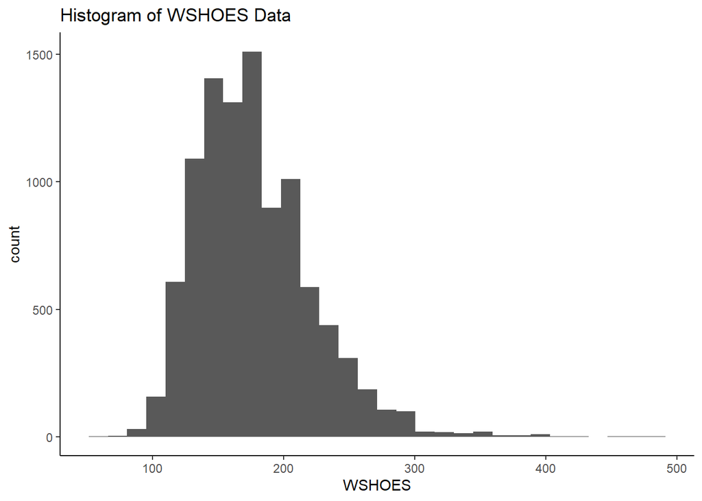

```r
ggplot(hs15, aes(x = WSHOES)) +
  geom_histogram() +
  theme_classic() +
  labs(
    title = "Histogram of WSHOES Data"
  )
```

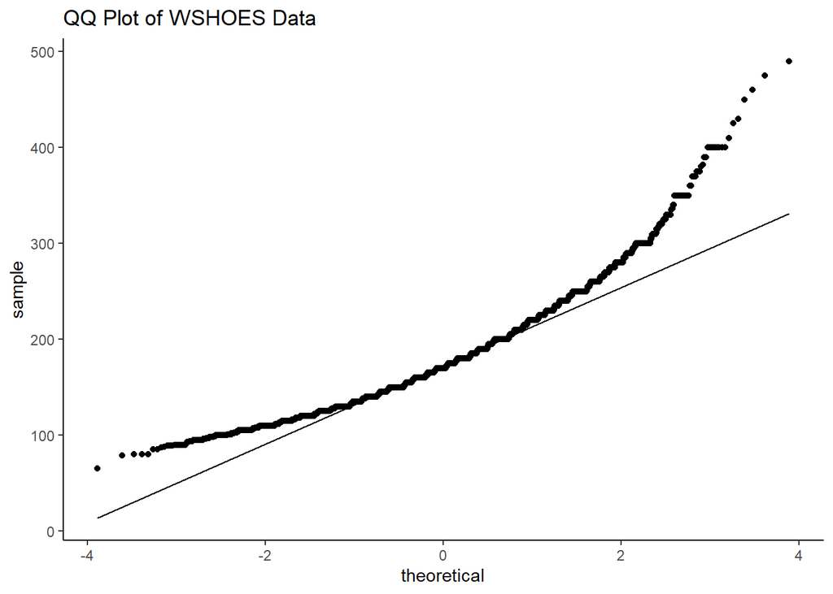

```r
ggplot(hs15, aes(sample = WSHOES)) +
  geom_qq() +
  geom_qq_line() +
  theme_classic() +
  labs(
    title = "QQ Plot of WSHOES Data"
  )
```

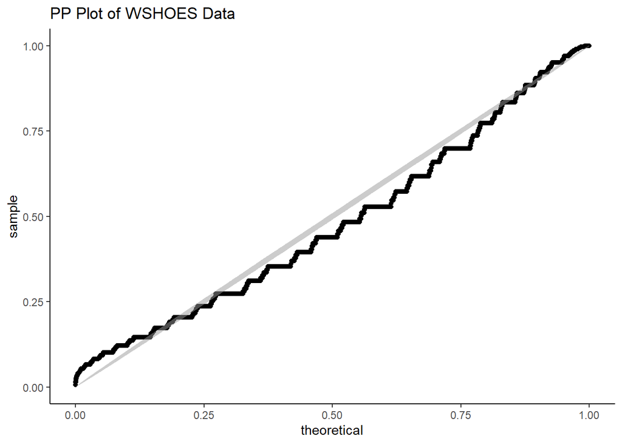

```r
ggplot(hs15, aes(sample = WSHOES)) +
  qqplotr::stat_pp_point() +
  qqplotr::stat_pp_band() +
  theme_classic() +
  labs(
    title = "PP Plot of WSHOES Data"
  )
```

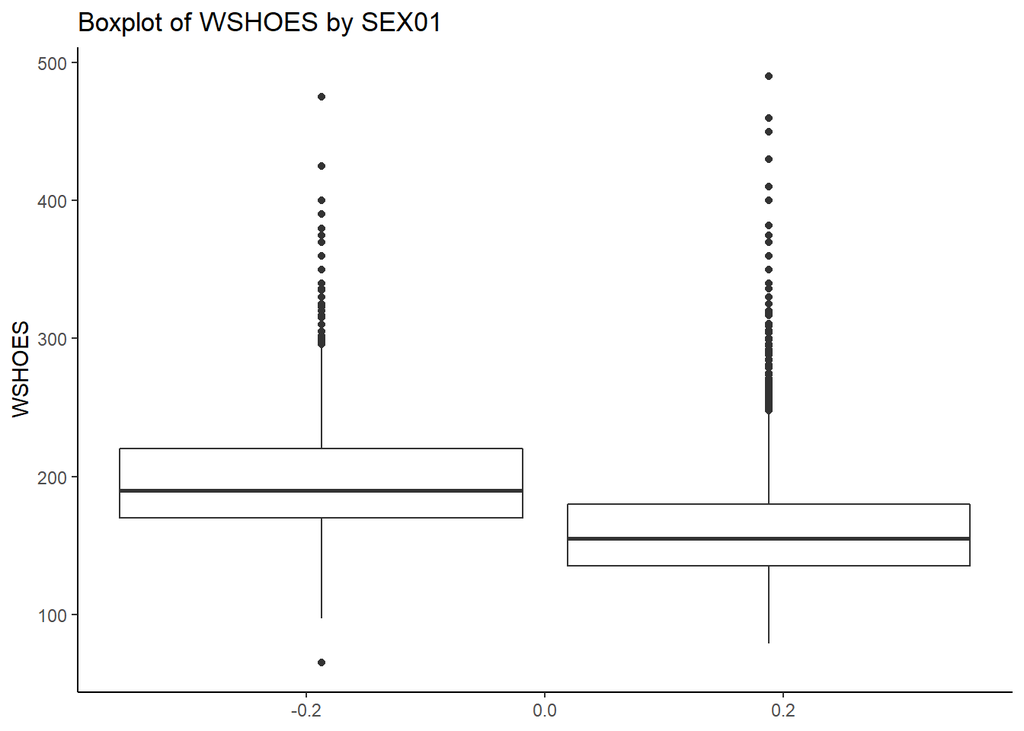

```r
ggplot(hs15, aes(y = WSHOES, group = as.factor(SEX01))) +
  geom_boxplot() +
  theme_classic() +
  labs(
    title = "Boxplot of WSHOES by SEX01"
  )
```

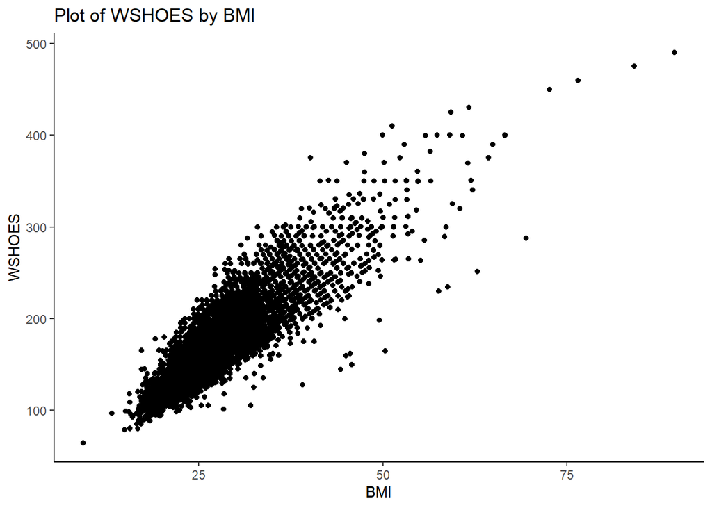

```r
ggplot(hs15, aes(x = BMI, y = WSHOES)) +
  geom_jitter() +
  theme_classic() +
  labs(
    title = "Plot of WSHOES by BMI"
  )
```

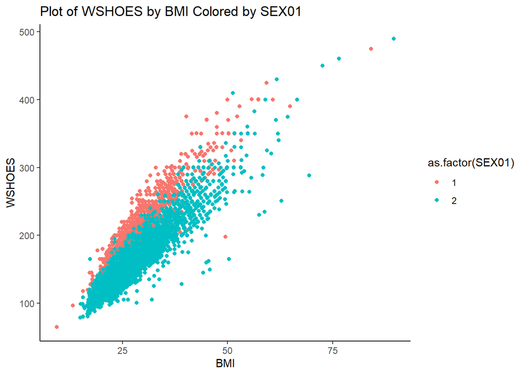

```r
ggplot(hs15, aes(x = BMI, y = WSHOES, color = as.factor(SEX01))) +
  geom_jitter() +
  theme_classic() +
  labs(
    title = "Plot of WSHOES by BMI Colored by SEX01"
  )
```

## 8. Run a correlation on weight without shoes, BMI, and age

```r
q8Data <- hs15 %>%
  select(WSHOES, BMI, RESPAGE) %>%
  drop_na()

cor(q8Data)
```

```
##              WSHOES        BMI     RESPAGE
## WSHOES   1.00000000 0.85844185 -0.05209302
## BMI      0.85844185 1.00000000  0.01085119
## RESPAGE -0.05209302 0.01085119  1.00000000
```

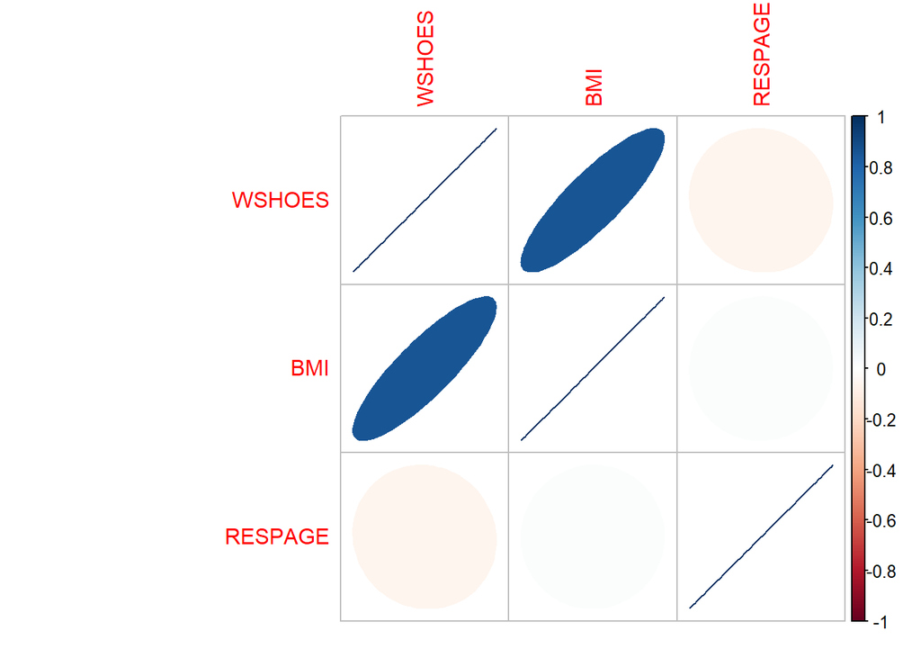

```r
corrplot(cor(q8Data), method = 'ellipse')
```

### Answer:

As can be inferred from the plot or taken directly from the matrix, it is clear there is a strong correlation with BMI and weight without shoes. There is a very week correlation with weight without shoes and age and no correlation with BMI and age.